# L13 - Multigroup Comparisons

## Lecture Goals

- Perform comparisons of multiple groups
  - Compare means/proportions
- Examine notion of variable (in)dependence
  - Test for independence of catergorical variables
- Readings
  - [ISRS](https://www.openintro.org/download.php?file=isrs1_tablet&referrer=/stat/textbook.php): ch. 3.4, 4.4

## Comparing Several Means

- LFS data: are *average earnings* the same for different levels of education?

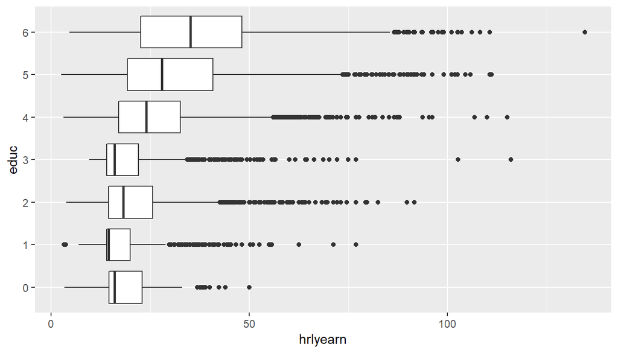

## Education Levels

| educ value | description |
| --- | --- |
| 0 | 0 to 8 years |
| 1 | Some secondary |
| 2 | Gr 11 to 13 |
| 3 | Some post secondary |
| 4 | Post secondary certificate or diploma |
| 5 | University: bachelors degree |
| 6 | University: graduate degree |

## Comparing Multiple Means

- Test equality of #\(m\) group means \(H_0: \mu_1 = \mu_2 = \cdots = \mu_m\)
- Could test all pairs (\(\mu_1=\mu_2\), \(\mu_2=\mu_3\), etc) and reject \(H_0\) if any one is rejected
  - Problem with inflated Type I Error ([multiple testing](https://en.wikipedia.org/wiki/Multiple_comparisons_problem))
- Instead, test for equality of all means *simultaneously*
  - Use ANalysis Of VAriance (*ANOVA*)
  - Test statistic based on inter/intra-group variance

## ANOVA

- Idea: compare variance (i.e. average distance) from common mean to that from individual means

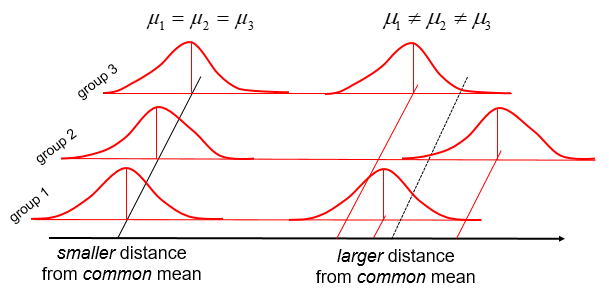

## Permutation Test for ANOVA

```r
library(coin)
lfs %>%
  mutate( educ = factor(educ) ) %>%
  kruskal_test( hrlyearn ~ educ , data = .,
                distribution = "approx" )
##
##  Approximative Kruskal-Wallis Test
##
## data:  hrlyearn by educ (0, 1, 2, 3, 4, 5, 6)
## chi-squared = 5350.5, p-value < 2.2e-16
```

## Comparing Multiple Proportions

- Is *unemployment rate* the same for different levels of education?
- **Contingency table** contains frequencies of *combinations* of two categorical variables

```r
lfs %>%
  filter(lfsstat != 4 ) %>%
  mutate( educ = factor(educ), empl = factor(lfsstat != 3)) %>%
  xtabs( ~ empl + educ, data = .)
##        educ
## empl        0     1     2     3     4     5     6
##   FALSE    33   251   502   200   574   683   296
##   TRUE    459  1816  6122  2237 10500 11457  5905
```

## Stacked Barplot

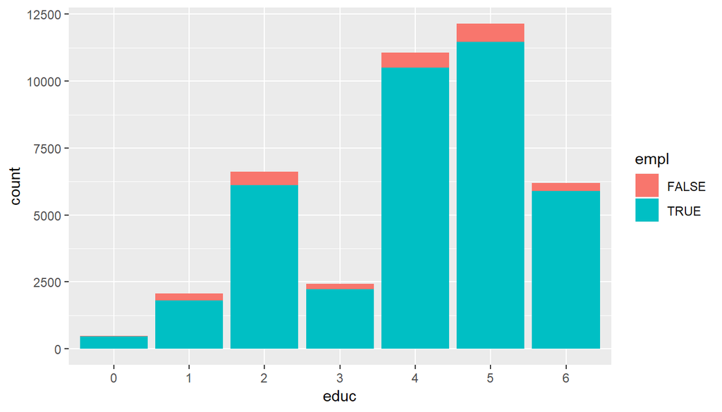

```r
lfs %>% filter(lfsstat != 4 ) %>%
  mutate( educ = factor(educ), empl = (lfsstat != 3)) %>%
  ggplot( aes(x = educ, fill = empl)) + geom_bar()
```

## Contingency Tables

- `prop.table()` for relative proportions
- `addmargins()` for table totals
- apply across rows/cols (`margin = 1/2`)

```r
lfs %>% filter(lfsstat != 4 ) %>%
  mutate( educ = factor(educ), empl = factor(lfsstat != 3)) %>%
  xtabs( ~ empl + educ, data = .) %>%
  prop.table( margin = 2 ) %>%
  addmargins( 1 ) %>%  round(4)
##        educ
## empl         0      1      2      3      4      5      6
##   FALSE 0.0671 0.1214 0.0758 0.0821 0.0518 0.0563 0.0477
##   TRUE  0.9329 0.8786 0.9242 0.9179 0.9482 0.9437 0.9523
##   Sum   1.0000 1.0000 1.0000 1.0000 1.0000 1.0000 1.0000
```

## Normalized Barplot

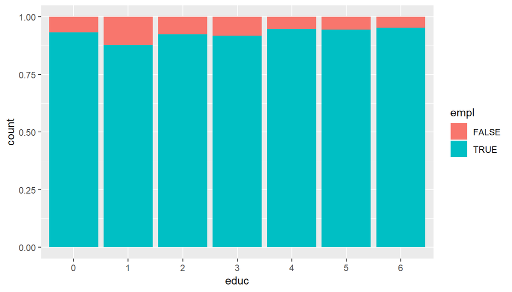

```r
lfs %>% filter(lfsstat != 4 ) %>%
  mutate( educ = factor(educ), empl = (lfsstat != 3)) %>%
  ggplot( aes(x = educ, fill = empl)) +
  geom_bar(position = "fill")
```

## Mosaic Plot

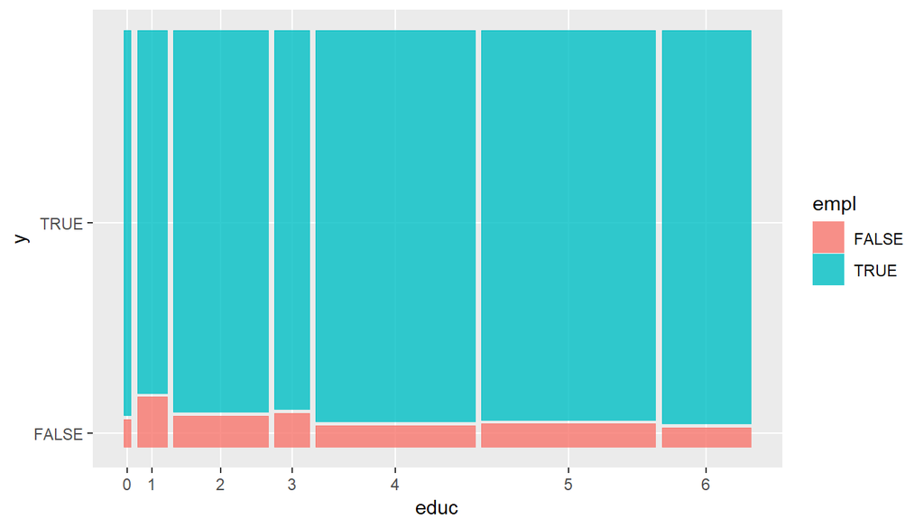

```r
library(ggmosaic)
lfs %>% filter(lfsstat != 4 ) %>%
  mutate( educ = factor(educ), empl = (lfsstat != 3)) %>%
  ggplot() + geom_mosaic(aes(x = product(educ), fill = empl)) + xlab("educ")
```

## Comparing Several Proportions

- Test equality of #\(m\) group proportions \(H_0: p_1 = p_2 = \cdots = p_m\)
- Under \(H_0\), it *does not matter* which group you are in
  - Proportion are *independent* of groups

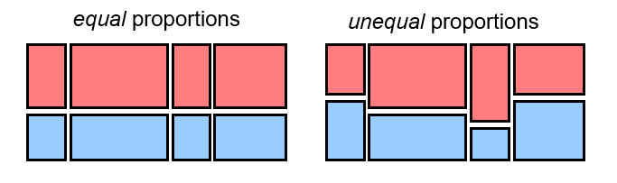

- Equivalent to testing **independence** of categorical variables (prop./group)

## Independence Test - Categorical Variables

- *Chi-square* (\(\chi^2\)) test statistic measures distance of *observed* from *expected* (under indep.) contingency table values
  - Sampling distribution under \(H_0\) by simulation (sample observations according to independent proportions)

```r
library(coin)
lfs %>% filter(lfsstat != 4 ) %>%
  mutate( educ = factor(educ), empl = factor(lfsstat != 3)) %>%
  chisq_test( empl ~ educ, data= ., distribution = "approx")
##
##  Approximative Pearson Chi-Squared Test
##
## data:  empl by educ (0, 1, 2, 3, 4, 5, 6)
## chi-squared = 212.93, p-value < 2.2e-16
```

## Example

- Chi-square test can be extended to multi-category variables
  - E.g. Are education and marital status related?

```r
lfs %>%
  mutate( educ = factor(educ), marstat = factor(marstat)) %>%
  chisq_test( marstat ~ educ, data= ., distribution = "approx")
##
##  Approximative Pearson Chi-Squared Test
##
## data:  marstat by educ (0, 1, 2, 3, 4, 5, 6)
## chi-squared = 10696, p-value < 2.2e-16
```

## Education vs Marital Status

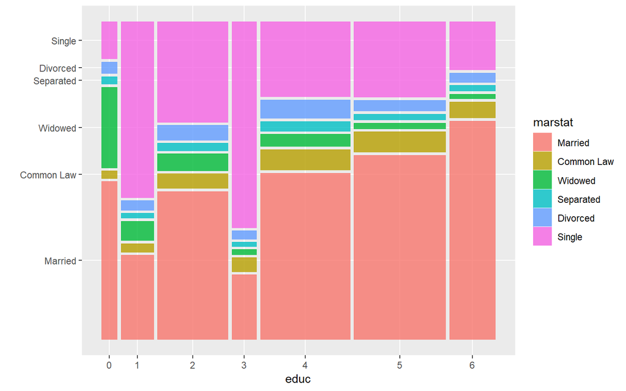

## General Independence Test

- `coin::independence_test()` provides general framework for comparing two or more groups
  - Formula-based argument `Y ~ X`
  - Compare `Y` values across levels of factor `X`
- \(Y\) variable type determines quantity to compare
  - Means for numeric \(Y\)
  - Proportions for factor \(Y\)
- Can use `independence_test()` for tests of equality of 2+ means/proportions